# Praca domowa 2

Yahor Lahunovich

## Dane

Dane wykorzystane w Pracy domowej 2 opisują wycenę nieruchmości. Każda obserwacja jest pewną nieruchmością, która posiada informacje takie jak powierzchnia, liczba pokoi, liczba łazienek i wiele więcj. Opis wszystkich kolumn w pliku `README.md`.

## Zadanie 1

Jak wygląda rozkład ceny nieruchomości w poszczególnych kodach pocztowych na przestrzeni lat? Rozważamy kody pocztowe, które mają więcej niż 280 posiadłości.

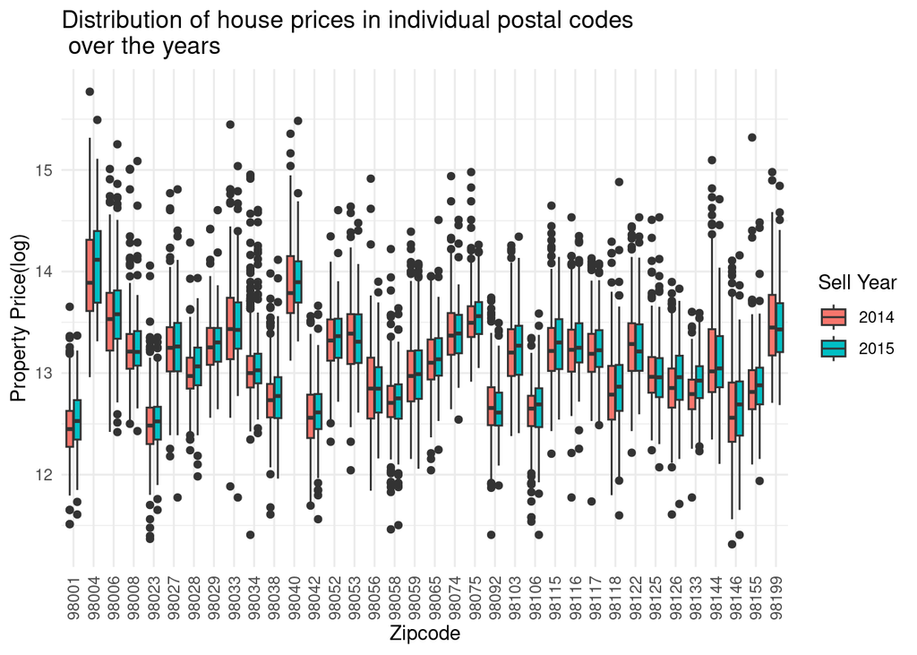

```r
# Tu umieść kod do wygenerowania odpowiedzi do zadania.
zipcode_df <- df$zipcode %>%
  table() %>%
  data.frame() %>%
  filter(Freq > 280)
colnames(zipcode_df)[1] <- "zipcode"
filtered_zipcode_df <- df %>%
  filter(zipcode %in% zipcode_df$zipcode) %>%
  mutate(log_price = log(price)) %>%
  mutate(sell_year = substr(date, 1, 4))

ggplot(filtered_zipcode_df, aes(x=as.factor(zipcode), y=log_price, fill = sell_year))+
  geom_boxplot() +
  theme_minimal() +
  theme(axis.text.x = element_text(angle = 90, vjust = 0.5, hjust=1))+
  labs(
    title = "Distribution of house prices in individual postal codes \n over the years",
    y = "Property Price(log)",
    x = "Zipcode",
    fill = "Sell Year",
  )
```

**Komentarz: na powyższym wykresie można zobacyć rozkład ceny nieruchomości w poszczególnych kodach pocztowych na przestrzeni lat. Średnia cena nieruchomości w większości obszarów kodów pocztowych nieco wzrosła pomiędzy rokiem 2014 a 2015.**

## Zadanie 2

Czy jest różnica w rozkładzie ceny nierchomości od powierzchni mieszkalnej uwzględniając podział na nieruchomości z piwnicą i bez?

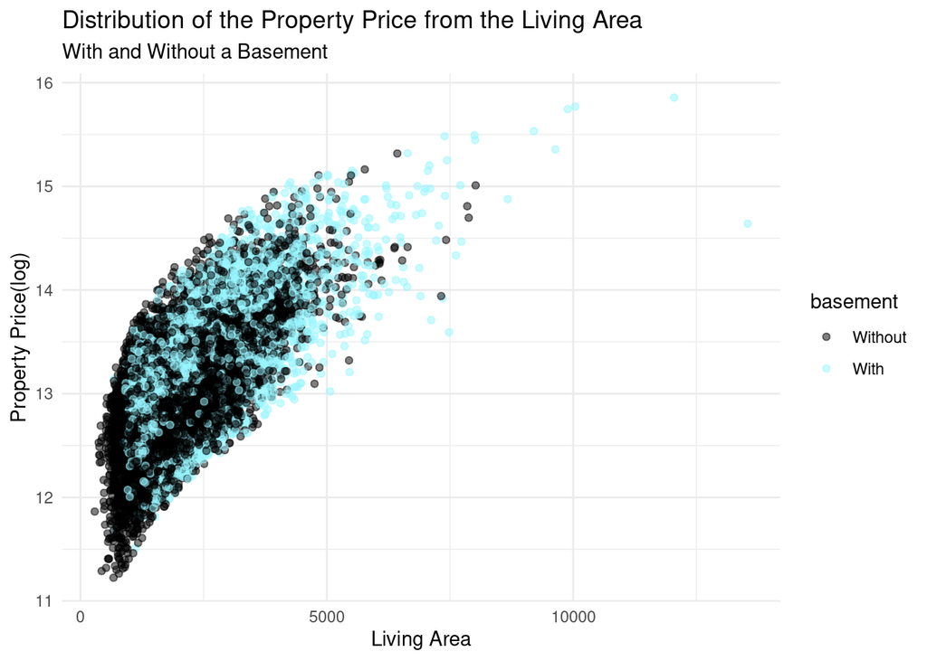

```r
# Tu umieść kod do wygenerowania odpowiedzi do zadania.

df <- df %>%
  mutate(basement = ifelse(sqft_basement != 0, TRUE, FALSE)) %>%
  mutate(log_price = log(price)) %>%
  mutate(th_price = price / 1000)
ggplot(data = df, aes(y=log(price), x=sqft_living, color=basement))+
  geom_point(alpha = 0.5) +
  labs(
    title = "Distribution of the Property Price from the Living Area",
    subtitle = "With and Without a Basement",
    x = "Living Area",
    y = "Property Price(log)",

  ) +
  scale_color_manual(labels = c("Without", "With"), values = c("black", "cadetblue1")) +
  theme_minimal()
```

## Zadanie 3

Jaka jest zależność pomiędzy jakością wykończenia nieruchomości a liczbą pięter?

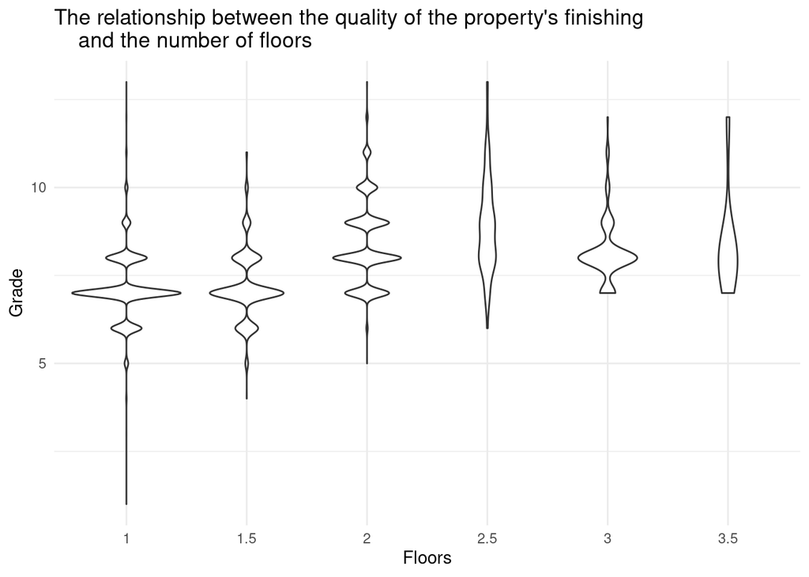

```r
# Tu umieść kod do wygenerowania odpowiedzi do zadania.

ggplot(df, aes(x=as.factor(floors), y=grade))+
  geom_violin()+
  theme_minimal()+
  labs(
    title = "The relationship between the quality of the property's finishing
    and the number of floors",
    x = "Floors",
    y = "Grade"
  )
```

## Zadanie 4

Jaka jest zależność między powierzchnią mieszkalną nieruchomości a powierzchnią gruntu w podziale na liczbę sypialni?

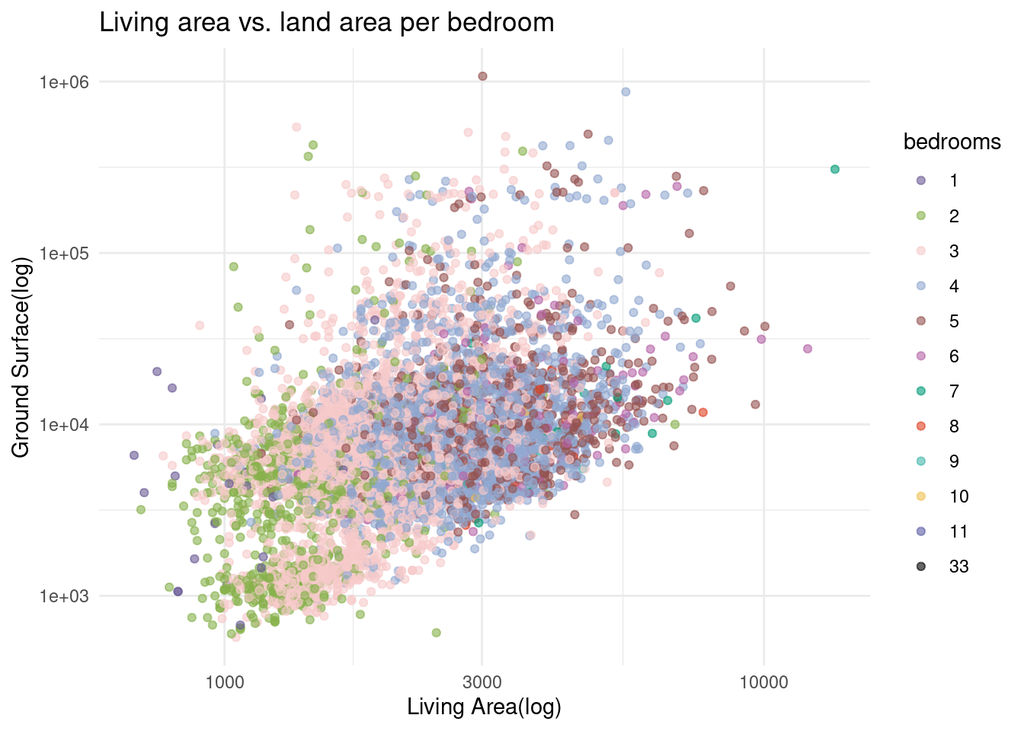

```r
# Tu umieść kod do wygenerowania odpowiedzi do zadania.

df$bedrooms <- as.factor(df$bedrooms)
bedroom_colors <- c(
  "0" = "#FF6F61", "1" = "#6B5B95", "2" = "#88B04B", "3" = "#F7CAC9",
  "4" = "#92A8D1", "5" = "#955251", "6" = "#B565A7", "7" = "#009B77",
  "8" = "#DD4124", "9" = "#45B8AC", "10" = "#EFC050", "11" = "#5B5EA6",
  "33" = "black"
)
ggplot(df[df$basement !=0,], aes(x=sqft_living, y=sqft_lot, color=bedrooms))+
  geom_point(alpha=0.6)+
  scale_color_manual(values = bedroom_colors)+
  labs(
    title = "Living area vs. land area per bedroom",
    x = "Living Area(log)",
    y = "Ground Surface(log)"
  )+
  scale_x_log10()+
  scale_y_log10()+
  theme_minimal()
```

**Komentarz: powyższy wykres nam mówi, że zależność jest liniowa, czego i spodziwałem się: im większa jest powierzchnia mieszkalna, tym wym większa jest powierzchnia gruntu. Ponadto, wraz ze wzrostem liczby sypialni w nieruchomości zwiększa się zarówno powierzchnia działki, jak i przestrzeń mieszkalna(oczywiste).**

## Zadanie 5

Rozważmy tylko nieruchomości, które miały remont. W której dekadzie było najwięcej przeprowadzonych remontów? Czy w poszczególnych dekadach jest porównywalny procent nieruchmości dla każdej wartości miary jakości i wykończenia nieruchomości?

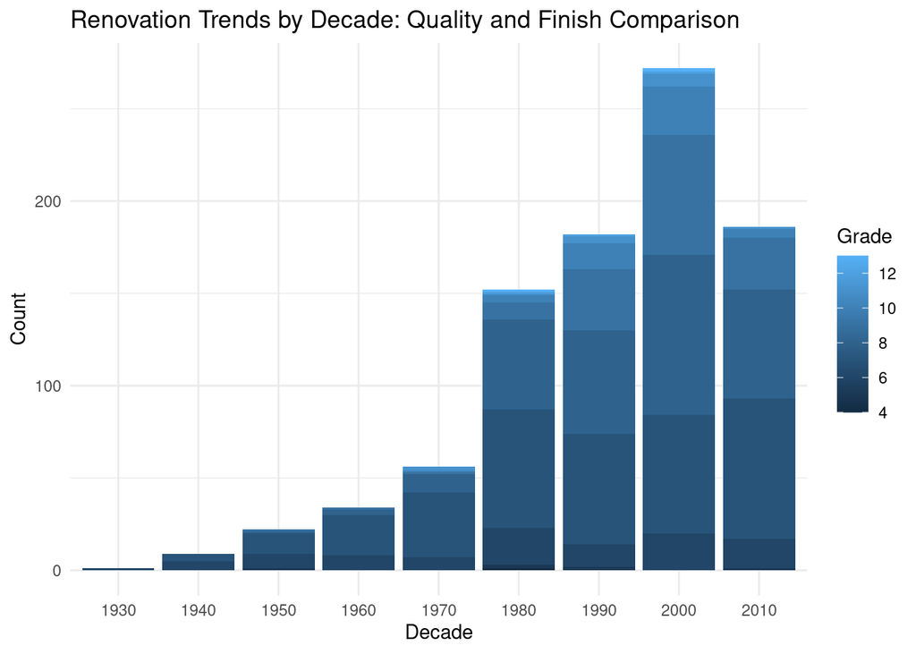

```r
# Tu umieść kod do wygenerowania odpowiedzi do zadania.
renovation_df <- df %>%
  filter(yr_renovated != 0) %>%
  mutate(decade = yr_renovated-(yr_renovated%%10)) %>%
  group_by(decade, grade) %>%
  summarise(count=n())

ggplot(renovation_df, aes(x=as.factor(decade), y=count, fill=grade))+
  geom_col()+
  labs(
    title = "Renovation Trends by Decade: Quality and Finish Comparison",
    x = "Decade",
    y = "Count",
    fill = "Grade"
  ) +
  theme_minimal()
```

**Komentarz: najwięcej remontów było w dekadzie 2000. Z tego wykresu również możemy zrozumieć, że domy ze średnią oceną mają więcej remontów, a domy, gdzie oceny są najwyższe mają mniej remontów. Czyli, domy ze średnią oceną mają więcej remontów.**

## Zadanie 6

Jak prezentuje się wartość minimalna, średnia i maksymalna ceny nieruchmości w podziele na rok budowy nieruchomości.

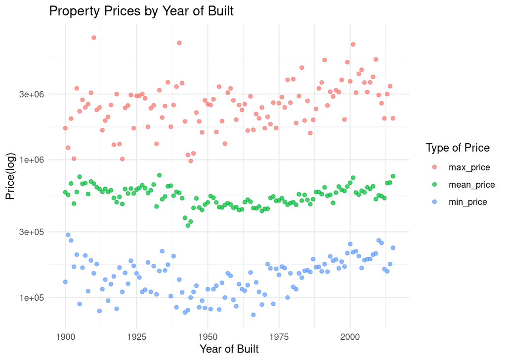

```r
# Tu umieść kod do wygenerowania odpowiedzi do zadania.

df_year <- df %>%
  group_by(yr_built) %>%
  summarise(mean_price = mean(price), min_price = min(price),
  max_price = max(price))

df_long <- df_year %>%
  select(yr_built, min_price, mean_price, max_price) %>%
  pivot_longer(cols = c(min_price, mean_price, max_price),
               names_to = "price_type",
               values_to = "price_value")

ggplot(df_long, aes(x = yr_built, y = price_value, color = price_type)) +
  geom_point(alpha=0.7) +
  labs(
    title = "Property Prices by Year of Built",
    x = "Year of Built",
    y = "Price(log)",
    color = "Type of Price"
  ) +
  scale_y_continuous() +
  scale_y_log10() +
  theme_minimal()
```

**Komentarz: Na tym wykresie możemy zobaczyć, że średnia cena na przestrzeni lat pozostała niemal taka sama, natomiast cena minimalna wzrosła w ostanich razach, a cena maksymalna zmienia się chaotycznie w zależności od roku**